# R Notebook

```r
library(ggplot2)
library(cowplot)
library(caret)
library(e1071)
library(pROC)
loan_data <- read.csv("C:/Users/rusha/Downloads/Multivariate/credit_risk_dataset.csv/credit_risk_dataset.csv")
loan_data
```

| person_age | loan_status | person_income | person_emp_length | loan_amnt | loan_int_rate | loan_percent_income | cb_person_cred_hist_length | loan_grade | cb_person_default_on_file |
| --- | --- | --- | --- | --- | --- | --- | --- | --- | --- |
| 22 | 1 | 59000 | 12 | 35000 | 16.02 | 0.59 | 3 | D | Y |
| 21 | 0 | 9600 | 5 | 1000 | 11.14 | 0.10 | 2 | B | N |
| 25 | 1 | 9600 | 1 | 5500 | 12.87 | 0.57 | 3 | C | N |
| 23 | 1 | 65500 | 4 | 35000 | 15.23 | 0.53 | 2 | C | N |
| 24 | 1 | 54400 | 8 | 35000 | 14.27 | 0.55 | 4 | C | Y |
| 21 | 1 | 9900 | 2 | 2500 | 7.14 | 0.25 | 2 | A | N |
| 26 | 1 | 77100 | 8 | 35000 | 12.42 | 0.45 | 3 | B | N |
| 24 | 1 | 78956 | 5 | 35000 | 11.11 | 0.44 | 4 | B | N |
| 24 | 1 | 83000 | 8 | 35000 | 8.90 | 0.42 | 2 | A | N |
| 21 | 1 | 10000 | 6 | 1600 | 14.74 | 0.16 | 3 | D | N |

[output cut: 488 more lines]

```r
str(loan_data)
```

```
## 'data.frame':    498 obs. of  10 variables:
##  $ person_age                : int  22 21 25 23 24 21 26 24 24 21 ...
##  $ loan_status               : int  1 0 1 1 1 1 1 1 1 1 ...
##  $ person_income             : int  59000 9600 9600 65500 54400 9900 77100 78956 83000 10000 ...
##  $ person_emp_length         : int  12 5 1 4 8 2 8 5 8 6 ...
##  $ loan_amnt                 : int  35000 1000 5500 35000 35000 2500 35000 35000 35000 1600 ...
##  $ loan_int_rate             : num  16 11.1 12.9 15.2 14.3 ...
##  $ loan_percent_income       : num  0.59 0.1 0.57 0.53 0.55 0.25 0.45 0.44 0.42 0.16 ...
##  $ cb_person_cred_hist_length: int  3 2 3 2 4 2 3 4 2 3 ...
##  $ loan_grade                : chr  "D" "B" "C" "C" ...
##  $ cb_person_default_on_file : chr  "Y" "N" "N" "N" ...
```

```r
# Check for NA values in each variable
sapply(loan_data, function(x) any(is.na(x)))
```

```
##                 person_age                loan_status
##                      FALSE                      FALSE
##              person_income          person_emp_length
##                      FALSE                       TRUE
##                  loan_amnt              loan_int_rate
##                      FALSE                       TRUE
##        loan_percent_income cb_person_cred_hist_length
##                      FALSE                      FALSE
##                 loan_grade  cb_person_default_on_file
##                      FALSE                      FALSE
```

```r
#converting loan_grade and cb_person_default_on_file as factor
loan_data$loan_grade <- as.factor(loan_data$loan_grade)
loan_data$cb_person_default_on_file <- as.factor(loan_data$cb_person_default_on_file)

#loan_status
loan_data[loan_data$loan_status == 0,]$loan_status <- "Not-Approved"
loan_data[loan_data$loan_status == 1,]$loan_status <- "Approved"
loan_data$loan_status <- as.factor(loan_data$loan_status)
```

```r
## Now determine how many rows have "NA" (aka "Missing data")
nrow(loan_data[is.na(loan_data$person_emp_length) | is.na(loan_data$loan_int_rate),])
```

```
## [1] 57
```

```r
loan_data[is.na(loan_data$person_emp_length) | is.na(loan_data$loan_int_rate),]
```

|  | person_age | loan_status | person_income | person_emp_length | loan_amnt | loan_int_rate | loan_percent_income | cb_person_cred_hist_length | loan_grade | cb_person_default_on_file |
| --- | --- | --- | --- | --- | --- | --- | --- | --- | --- | --- |
| 40 | 23 | Approved | 71500 | 3 | 30000 | NA | 0.42 | 4 | D | N |
| 51 | 24 | Approved | 78000 | 4 | 30000 | NA | 0.38 | 4 | D | Y |
| 58 | 23 | Not-Approved | 277000 | 3 | 35000 | NA | 0.13 | 4 | A | N |
| 60 | 24 | Not-Approved | 12000 | 2 | 1750 | NA | 0.15 | 3 | E | Y |
| 63 | 26 | Approved | 263000 | 0 | 10000 | NA | 0.04 | 4 | B | N |
| 71 | 25 | Approved | 12000 | 0 | 3000 | NA | 0.25 | 3 | C | N |
| 72 | 22 | Approved | 56950 | 6 | 28000 | NA | 0.49 | 2 | A | N |
| 85 | 26 | Approved | 12000 | 0 | 2700 | NA | 0.23 | 4 | A | N |
| 86 | 22 | Approved | 108000 | 6 | 28000 | NA | 0.26 | 4 | B | N |
| 88 | 24 | Approved | 69000 | 2 | 27600 | NA | 0.40 | 2 | A | N |

[output cut: 47 more lines]

```r
##We see the column loan_int_rate has more missing values than person_emp_length
#dropping rows
loan_data <- loan_data[!(is.na(loan_data$loan_int_rate) | is.na(loan_data$person_emp_length)),]
nrow(loan_data)
```

```
## [1] 441
```

1. Model Development

```r
## Exploratory Analysis
xtabs(~ loan_status + person_age, data=loan_data)
```

```
##               person_age
## loan_status    21 22 23 24 25 26 144
##   Approved     23 43 59 51 37 31   0
##   Not-Approved 10 14 35 45 55 36   2
```

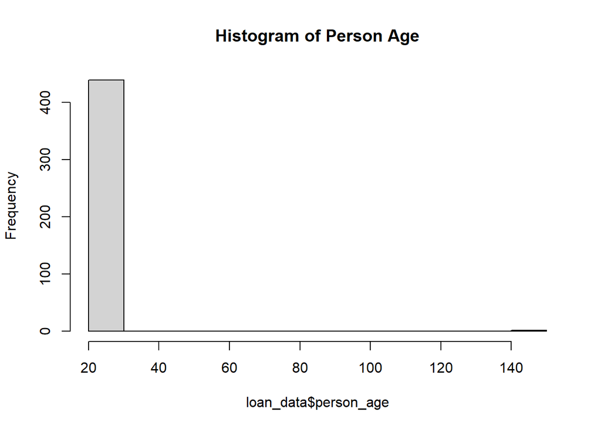

```r
#Removing 2 observed values of age 144. Outliers
hist(loan_data$person_age, main = "Histogram of Person Age")
```

```r
loan_data$z_score_age <- scale(loan_data$person_age)
# Define threshold
threshold <- 3

# Remove outliers based on threshold
loan_data <- loan_data[abs(loan_data$z_score_age) <= threshold, ]

# Remove the z_score_age column as it's no longer needed
loan_data$z_score_age <- NULL

# Check the dimensions of the filtered data
dim(loan_data)
```

```
## [1] 439  10
```

```r
xtabs(~ loan_status + person_age, data=loan_data)
```

```
##               person_age
## loan_status    21 22 23 24 25 26
##   Approved     23 43 59 51 37 31
##   Not-Approved 10 14 35 45 55 36
```

```r
#xtabs(~ loan_status + person_income, data=loan_data)
```

```r
xtabs(~ loan_status + person_emp_length, data=loan_data)
```

```
##               person_emp_length
## loan_status     0  1  2  3  4  5  6  7  8  9 10 11 12
##   Approved     35 28 31 25 20 22 26 23 14 17  2  0  1
##   Not-Approved 24 13 23 19 14 20 15 16 19 17 13  1  1
```

```r
xtabs(~ loan_status + loan_amnt, data=loan_data)
```

```
##               loan_amnt
## loan_status    1000 1200 1400 1500 1600 1750 1800 2000 2100 2275 2400 2500 2600
##   Approved        0    0    0    0    1    1    0    1    0    0    1    5    0
##   Not-Approved    3    1    2    3    1    3    1    3    1    1    0    2    1
##               loan_amnt
## loan_status    2800 3000 3175 3200 3250 3300 3500 3600 3625 3650 4000 4200 4375
##   Approved        1    5    1    1    1    1    1    2    1    1    5    2    1
##   Not-Approved    0    2    0    0    0    0    1    0    0    0    0    0    0
##               loan_amnt
## loan_status    4500 4575 4600 4750 4900 4950 5000 5375 5400 5500 5600 6000 6100
##   Approved        3    1    1    2    1    1    3    1    1    2    1    3    1
##   Not-Approved    0    0    0    0    0    0    1    0    0    0    0    0    0
##               loan_amnt
## loan_status    6200 6250 7200 7500 7750 7800 8000 8800 9000 9600 9950 10000
##   Approved        1    3    0    0    1    0    0    0    0    0    0     3
##   Not-Approved    0    0    1    1    0    1    1    1    2    2    1     8
##               loan_amnt
## loan_status    11900 12000 13000 14000 15000 15250 15500 16000 18000 20000
##   Approved         1     0     1     0     0     0     0     0     0     2
##   Not-Approved     0    11     1     2     4     1     1     2     5    19
##               loan_amnt
## loan_status    21000 21600 22000 22250 22400 22500 22750 23000 23050 23400
##   Approved         0     0     4     1     1     2     1     5     0     1
##   Not-Approved     3     1     2     0     0     0     0     0     1     0
##               loan_amnt
## loan_status    23575 23600 23750 24000 24150 24250 24500 24750 25000 25300
##   Approved         1     1     0    30     1     7     0     2    83     1
##   Not-Approved     0     1     1    16     0     9     2     0    46     0
##               loan_amnt
## loan_status    25475 25600 26000 27000 27050 27500 28000 29100 30000 31050
##   Approved         1     0     1     1     1     1     4     1    11     1
##   Not-Approved     0     1     0     0     0     0     5     0     6     0
##               loan_amnt
## loan_status    32000 32500 33000 33950 34000 34800 35000
##   Approved         0     1     1     1     1     0    12
##   Not-Approved     1     0     0     0     0     1     9
```

```r
#xtabs(~ loan_status + loan_int_rate, data=loan_data)
```

```r
xtabs(~ loan_status + loan_percent_income, data=loan_data)
```

```
##               loan_percent_income
## loan_status    0.01 0.02 0.03 0.04 0.05 0.06 0.07 0.08 0.09 0.1 0.11 0.12 0.13
##   Approved        0    0    1    0    1    1    1    0    0   1    1    2    0
##   Not-Approved    5    1    4    5    6   14   10   13    7  10   10   15    9
##               loan_percent_income
## loan_status    0.14 0.15 0.16 0.17 0.18 0.19 0.2 0.21 0.22 0.23 0.24 0.25 0.26
##   Approved        1    1    8    5    3    2   0    5    4    5    1    3    3
##   Not-Approved    9    5    5    3    4   11   3    6    5    4    4    6    0
##               loan_percent_income
## loan_status    0.27 0.28 0.29 0.3 0.31 0.32 0.33 0.34 0.35 0.36 0.37 0.38 0.39
##   Approved        7    9    1   5   15   15    9   10   11    6    9   11    6
##   Not-Approved    8    3    4   6    0    0    0    0    0    0    0    0    0
##               loan_percent_income
## loan_status    0.4 0.41 0.42 0.43 0.44 0.45 0.46 0.47 0.48 0.49 0.5 0.51 0.52
##   Approved       8    5   13    3    2    7    2    2    2    2   8    6    3
##   Not-Approved   0    0    0    0    0    0    0    0    0    0   0    0    0
##               loan_percent_income
## loan_status    0.53 0.54 0.55 0.56 0.57 0.59 0.6 0.63 0.64 0.72
##   Approved        4    1    1    3    2    3   1    1    1    1
##   Not-Approved    0    0    0    0    0    0   0    0    0    0
```

```r
xtabs(~ loan_status + cb_person_cred_hist_length, data=loan_data)
```

```
##               cb_person_cred_hist_length
## loan_status     2  3  4
##   Approved     84 84 76
##   Not-Approved 58 60 77
```

```r
xtabs(~ loan_status + loan_grade, data=loan_data)
```

```
##               loan_grade
## loan_status     A  B  C  D  E  F  G
##   Approved     36 65 39 63 27 11  3
##   Not-Approved 39 87 41 19  5  4  0
```

```r
xtabs(~ loan_status + cb_person_default_on_file, data=loan_data)
```

```
##               cb_person_default_on_file
## loan_status      N   Y
##   Approved     169  75
##   Not-Approved 160  35
```

```r
str(loan_data)
```

```
## 'data.frame':    439 obs. of  10 variables:
##  $ person_age                : int  22 21 25 23 24 21 26 24 24 21 ...
##  $ loan_status               : Factor w/ 2 levels "Approved","Not-Approved": 1 2 1 1 1 1 1 1 1 1 ...
##  $ person_income             : int  59000 9600 9600 65500 54400 9900 77100 78956 83000 10000 ...
##  $ person_emp_length         : int  12 5 1 4 8 2 8 5 8 6 ...
##  $ loan_amnt                 : int  35000 1000 5500 35000 35000 2500 35000 35000 35000 1600 ...
##  $ loan_int_rate             : num  16 11.1 12.9 15.2 14.3 ...
##  $ loan_percent_income       : num  0.59 0.1 0.57 0.53 0.55 0.25 0.45 0.44 0.42 0.16 ...
##  $ cb_person_cred_hist_length: int  3 2 3 2 4 2 3 4 2 3 ...
##  $ loan_grade                : Factor w/ 7 levels "A","B","C","D",..: 4 2 3 3 3 1 2 2 1 4 ...
##  $ cb_person_default_on_file : Factor w/ 2 levels "N","Y": 2 1 1 1 2 1 1 1 1 1 ...
```

```r
logistic_simple <- glm(loan_status ~ person_age, data=loan_data, family="binomial")
summary(logistic_simple)
```

```
##
## Call:
## glm(formula = loan_status ~ person_age, family = "binomial",
##     data = loan_data)
##
## Coefficients:
##             Estimate Std. Error z value Pr(>|z|)
## (Intercept) -7.51867    1.64187  -4.579 4.66e-06 ***
## person_age   0.30576    0.06857   4.459 8.24e-06 ***
## ---
## Signif. codes:  0 '***' 0.001 '**' 0.01 '*' 0.05 '.' 0.1 ' ' 1
##
## (Dispersion parameter for binomial family taken to be 1)
##
##     Null deviance: 603.10  on 438  degrees of freedom
## Residual deviance: 582.11  on 437  degrees of freedom
## AIC: 586.11
##
## Number of Fisher Scoring iterations: 4
```

Identifying if the model is good/bad check for intercept and person_age coefficient check for low AIC score check for *** ie significant

```r
## The intercept is the log(odds) a female will be unhealthy. This is because
## female is the first factor in "sex" (the factors are ordered,
## alphabetically by default,"female", "male")
## Now let's look at the second coefficient...
##   sexM        1.2737     0.2725   4.674 2.95e-06 ***
##
## sexM is the log(odds ratio) that tells us that if a sample has sex=M, the
## odds of being unhealthy are, on a log scale, 1.27 times greater than if
## a sample has sex=F.
#female.log.odds <- log(25 / 71)
#female.log.odds
# Now you know how these are calculated
#male.log.odds.ratio <- log((112 / 89) / (25/71))
#male.log.odds.ratio
```

2. Model Acceptance

```r
#let's  see what this logistic regression predicts
predicted.data <- data.frame(probability.of.loan_status=logistic_simple$fitted.values,age=loan_data$person_age)
predicted.data
```

|  | probability.of.loan_status | age |
| --- | --- | --- |
| 1 | 0.3117674 | 22 |
| 2 | 0.2501836 | 21 |
| 3 | 0.5313145 | 25 |
| 4 | 0.3808114 | 23 |
| 5 | 0.4550363 | 24 |
| 6 | 0.2501836 | 21 |
| 7 | 0.6061568 | 26 |
| 8 | 0.4550363 | 24 |
| 9 | 0.4550363 | 24 |
| 10 | 0.2501836 | 21 |

[output cut: 429 more lines]

```r
# We can plot the data
#ggplot(data=predicted.data ,aes(x=age, y=probability.of.loan_status))+ geom_point(aes(color=age), size=5) + xlab("Age") + ylab("Predicted probability of getting a loan")

xtabs(~ probability.of.loan_status + age, data=predicted.data)
```

```
##                           age
## probability.of.loan_status 21 22 23 24 25 26
##          0.250183632104906 33  0  0  0  0  0
##          0.311767419936242  0 57  0  0  0  0
##          0.38081141986822   0  0 94  0  0  0
##          0.455036346663974  0  0  0 96  0  0
##          0.531314456467254  0  0  0  0 92  0
##          0.606156783012672  0  0  0  0  0 67
```

3. Residual Analysis and Prediction

```r
logistic <- glm(loan_status ~ ., data=loan_data, family="binomial")
summary(logistic)
```

```
##
## Call:
## glm(formula = loan_status ~ ., family = "binomial", data = loan_data)
##
## Coefficients:
##                              Estimate Std. Error z value Pr(>|z|)
## (Intercept)                 6.415e+00  4.448e+00   1.442  0.14929
## person_age                 -6.011e-02  1.686e-01  -0.356  0.72147
## person_income              -2.134e-05  6.954e-06  -3.069  0.00215 **
## person_emp_length           5.370e-02  6.600e-02   0.814  0.41582
## loan_amnt                   3.231e-04  5.936e-05   5.442 5.26e-08 ***
## loan_int_rate               2.576e-03  2.075e-01   0.012  0.99009
## loan_percent_income        -4.655e+01  6.621e+00  -7.031 2.05e-12 ***
## cb_person_cred_hist_length  5.514e-01  2.600e-01   2.121  0.03394 *
## loan_gradeB                 2.214e-01  9.421e-01   0.235  0.81423
## loan_gradeC                 1.785e-01  1.445e+00   0.124  0.90167
## loan_gradeD                -2.484e+00  1.791e+00  -1.387  0.16551
## loan_gradeE                -3.733e+00  2.159e+00  -1.730  0.08371 .
## loan_gradeF                -3.642e+00  2.517e+00  -1.447  0.14798
## loan_gradeG                -1.944e+01  1.355e+03  -0.014  0.98856
## cb_person_default_on_fileY -1.805e-01  5.736e-01  -0.315  0.75305
## ---
## Signif. codes:  0 '***' 0.001 '**' 0.01 '*' 0.05 '.' 0.1 ' ' 1
##
## (Dispersion parameter for binomial family taken to be 1)
##
##     Null deviance: 603.10  on 438  degrees of freedom
## Residual deviance: 180.07  on 424  degrees of freedom
## AIC: 210.07
##
## Number of Fisher Scoring iterations: 15
```

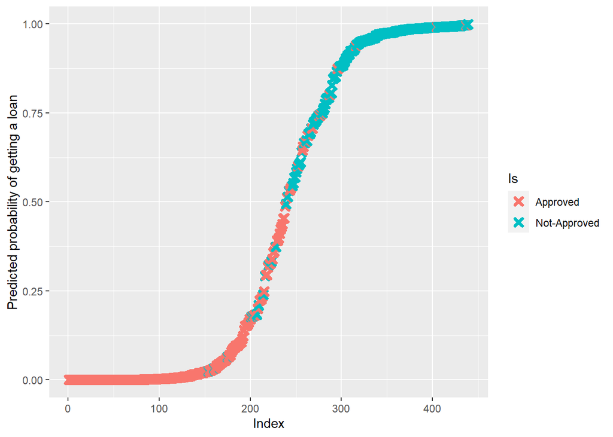

```r
predicted.data <- data.frame(probability.of.ls=logistic$fitted.values,ls=loan_data$loan_status)
predicted.data <- predicted.data[order(predicted.data$probability.of.ls, decreasing=FALSE),]
predicted.data$rank <- 1:nrow(predicted.data)
## Lastly, we can plot the predicted probabilities for each sample having
## heart disease and color by whether or not they actually had heart disease
ggplot(data=predicted.data, aes(x=rank, y=probability.of.ls)) +
geom_point(aes(color=ls), alpha=1, shape=4, stroke=2) +
xlab("Index") +
ylab("Predicted probability of getting a loan")
```

5. Model Accuracy

```r
# Confusion matrix
conf_mat <- table(Actual = loan_data$loan_status, Predicted = ifelse(logistic$fitted.values > 0.5, "Approved", "Not-Approved"))
print(conf_mat)
```

```
##               Predicted
## Actual         Approved Not-Approved
##   Approved           18          226
##   Not-Approved      182           13
```

```r
# Calculate accuracy
accuracy <- sum(diag(conf_mat)) / sum(conf_mat)
print(paste("Accuracy:", accuracy))
```

```
## [1] "Accuracy: 0.0706150341685649"
```

```r
# Calculate precision
precision <- conf_mat["Approved", "Approved"] / sum(conf_mat[, "Approved"])
print(paste("Precision:", precision))
```

```
## [1] "Precision: 0.09"
```

```r
# Calculate recall
recall <- conf_mat["Approved", "Approved"] / sum(conf_mat["Approved", ])
print(paste("Recall:", recall))
```

```
## [1] "Recall: 0.0737704918032787"
```

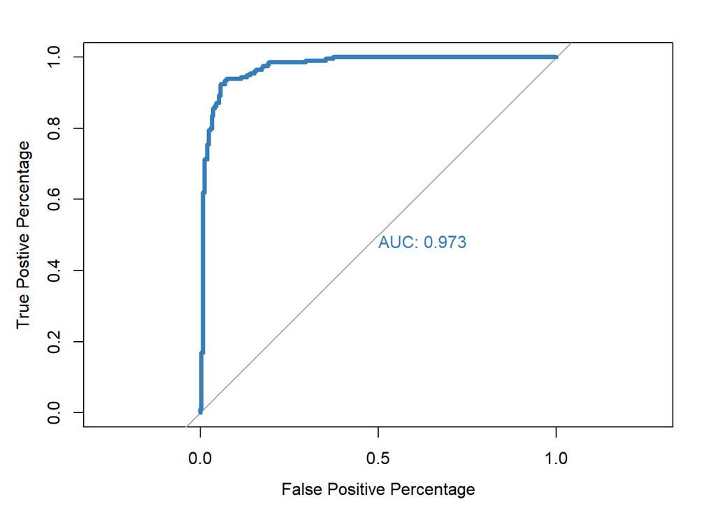

```r
# ROC curve
roc_obj <- roc(loan_data$loan_status, logistic$fitted.values)
plot(roc_obj, xlab="False Positive Percentage", ylab="True Postive Percentage", legacy.axes=TRUE, col="#377eb8", lwd=4, percent=TRUE, print.auc=TRUE)
```

Insights: The model only predicts 18 cases of Approved and 13 cases of not-approved correctly.

The accuracy of the modelis approximately 7.06%. This indicates that the model’s overall predictive accuracy is quite low.

Precision measures the proportion of correctly predicted “Approved” loans out of all predicted “Approved” cases, is 9%, indicating that only a small fraction of cases predicted as “Approved” are actually “Approved”.

The recall of the model is approximately 7.38%, indicating that the model correctly identifies only a small portion of “Approved” loans.

The Area Under the Curve (AUC) is a measure of the model’s ability to distinguish between “Approved” and “Not-Approved” loans. The AUC value of 0.973 indicates that the model has good discriminatory power.